# Part II - Explanatory data analysis of FordGoBike SF Bay area February 2019 trip data.

## by Gilbert Adikankwu

## Investigation Overview

My goal for this investigation is look at how trip duration can be predicted based off the typical details of any trip.

## Dataset Overview

This data consist of 183412 bike trips, including features like duration, members age and user type.

## Distribution of trip duration.

On a Log scale of trip duration in minutes, the distribution of trip duration looks roughly unimodal with one peak which indicates that most of the trips lasted for approximately 10 minutes.

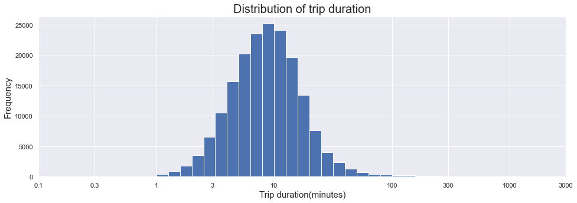

## Distribution of members age

Most of the members are under age of 40 years. The distribution is righ-skewed and roughly unimodal. Also, there are outlier ages.

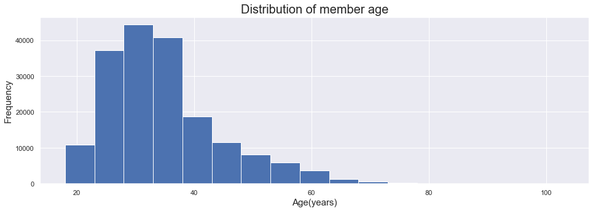

## Trip duration vs member age

Members aged 18 - 48 years did the majority of all the trips that lasted for a duration of 200 minutes and above.

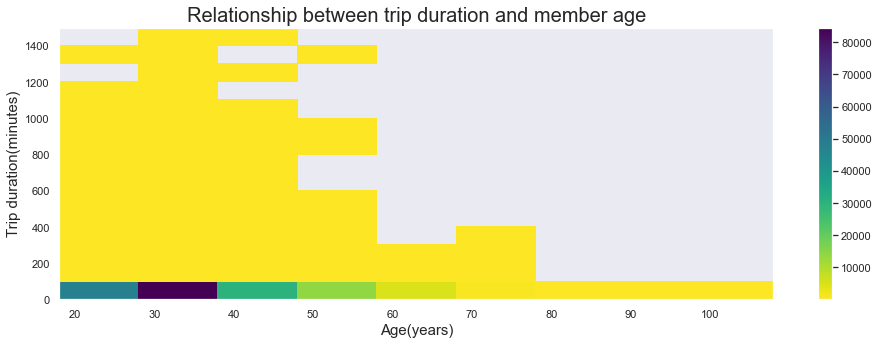

## Average trip duration of each day of the week.

Despite Saturday and Sunday been the days of the week with the lowest number of trips, they both have a significantly higher average trip duration when compared to the other days.

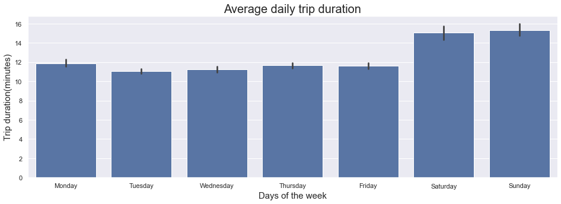

## Average trip duration of each user types

The average trip duration of Customer users is more than twice the average trip duration of the subscriber users.

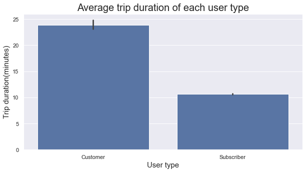

## Trip duration by week day and user type

On Every day of the week the customers tend to use more time than the subscribers on the bikes.

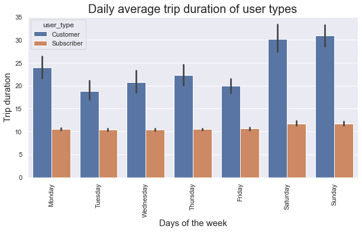